# Learning Ordination

## Overview

Today you are going to step through using the `vegan` package to conduct a non-metric multidimensional scaling (“NMDS”) ordination of our forests, using the number of trees of each species in each plot as the variable we will use to differentiate communities.

## Set things up

First, set things up: You will need some packages we haven’t used before, so remember that the code `install.packages("packagename")` installs a new package in your RStudio environment and that you then need `library(packagename)` to activate the package(s).

Set up your workspace in the code chunk below, and include installation of the packages `vegan`, `ggpubr` and `ggrepel`. We will also use a package called `ggvegan` for plotting the results of our ordination. It cannot be installed in the normal way, so add code to install the package “devtools”. Once you have it installed, add this line of code:

`devtools::install_github("gavinsimpson/ggvegan")`.

```r
rm(list = ls())
library(tidyverse)
library(vegan)
library(here)
library(ggpubr)
library(ggrepel)
library(devtools)
```

```
Error in library(devtools) : there is no package called ‘devtools’
```

Next, we need some data.

Once you have the data in your Data folder, write code in the code box below to import the data as a new dataframe called Trees.

There may be a wonky first column X. If so, use your incredible R skills to delete it from the data frame.

The dataframe Trees has 23 columns (once you get rid of the X column). The first two identify the forest and plot, respectively. The remainder identify the number of trees for each species that we observed across all of our forest sampling.

## Grab the columns with forest, plot

We’ll need to grab the columns contining information about forest and plot number to use later in our plots.

Write code in the box below that extracts the first two columns of Trees and saves them as a new dataframe called “PlotInfo”

## Run the ordination.

We use the `vegan` package to conduct the ordination.

The following code block creates an object called TreeOrd by running the `metaMDS` function in the `vegan` package. This function conducts a NMDS ordination.

```r
TreeOrd<-metaMDS(trees[, 3:23], distance = "bray", k = 2)
```

```
Wisconsin double standardization
*** Best solution repeated 8 times
```

## Interpret the results

Notice that the TreesOrd object in your Environment window is a list of 36 different items! First, take a look at the “stress” associated with the model. Stress is a measure of how well our two-dimensional representation captures the information in our 21-dimensional space (the 21 species). In general, stress values need to be less that 0.2 to be acceptable.

Let’s look at the stress associated with this ordination:

```r
TreeOrd$stress
```

```
[1] 0.1282567
```

We can also look at the stressplot

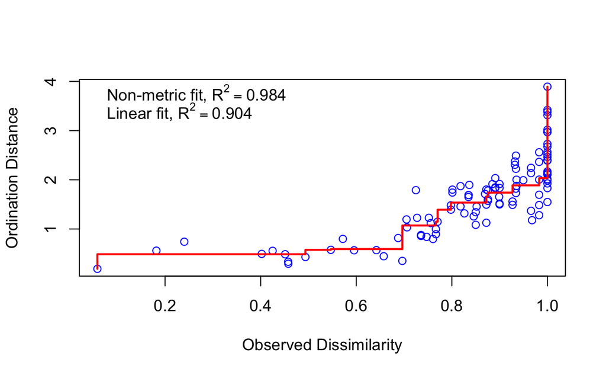

```r
stressplot(TreeOrd)
```

## Plot the results for further interpretation.

We can plot the results using the `ggvegan` and `ggplot2` packages. Make sure you have them turned on.

The first step is to use a function called `fortify` to rearrange the output into a long-format dataframe familiar to ggplot2. Then we can make a basic plot. Then we will spruce up our basic plot.

### Fortify the result

```r
ForPlotting<-fortify(TreeOrd)
```

Now we will make our plots from the new ForPlotting dataframe.

### Make a basic plot

[output not shown]

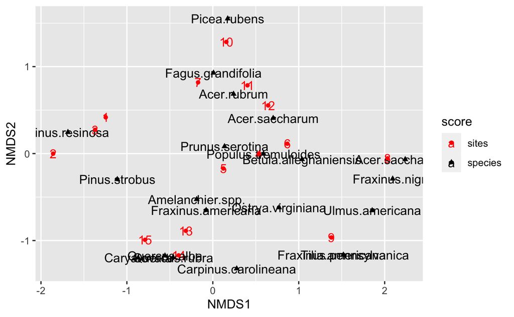

```r
ggplot(ForPlotting, aes(NMDS1,NMDS2,group = score))+
   geom_text(aes(label=label, color = score))+
   scale_color_manual(values = c(sites = "brown", species = "green"))+
   geom_point(aes(color=score, shape =score))+
   scale_color_manual(values = c(sites = "red", species = "black"))
```

This plot is in the direction that we want, but we can improve upon it considerably.

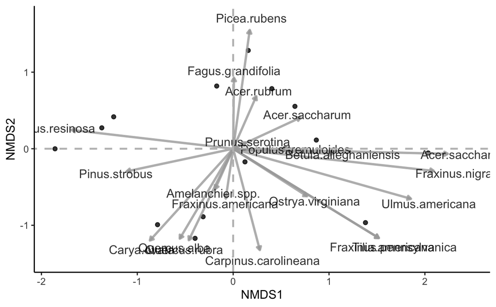

```r
ggplot()+
   geom_point(data = subset(ForPlotting, score =="sites"),
              mapping = aes(x = NMDS1, y = NMDS2),
              alpha = 0.8)+
   geom_segment(data=subset(ForPlotting, score == "species"),
                mapping = aes(x = 0, y = 0, xend = NMDS1,   yend=NMDS2),
                 arrow = arrow(length = unit(0.015, "npc"),
               type = "closed"),
                 color = "darkgray",
                 size = 1,
               alpha = 0.8)+
   geom_text(data = subset(ForPlotting, score == "species"),
             mapping = aes(label = label, x = NMDS1*1.1, y=NMDS2*1.1), alpha = 0.8)+
   geom_abline(intercept = 0, slope = 0, linetype = "dashed", size = 0.8, color = "gray")+
   geom_vline(aes(xintercept = 0), linetype = "dashed", size = 0.8, color = "gray")+
   theme(
      panel.grid.major = element_blank(),
      panel.grid.minor = element_blank(),
      panel.background = element_blank(),
      axis.line = element_line(color = "black"),
      legend.position = "none")
```

```r
NA
NA
```

That plot has a lot of information in one plot - let’s see if we can pull information out into two separate plots for easier interpretation. Regard the following code which creates a plot called p1 which puts each site on a plot, colored by forest, and numbered by plot number.

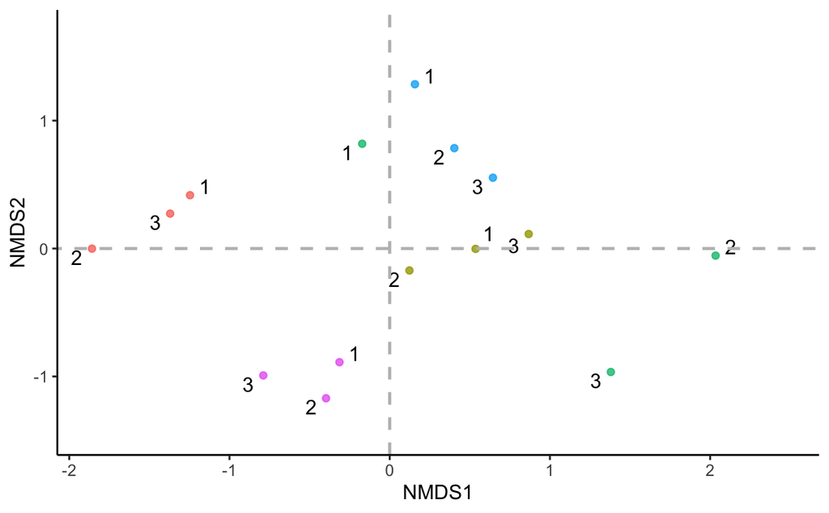

```r
p1<-ggplot()+
   geom_point(data = subset(ForPlotting, score =="sites"),
              mapping = aes(x = NMDS1, y = NMDS2, color = PlotInfo$Forest),
              alpha = 0.8)+
  geom_text_repel(data = subset(ForPlotting, score =="sites"), mapping = aes(x = NMDS1, y = NMDS2,label = PlotInfo$Plot))+
   geom_segment(data=subset(ForPlotting, score == "species"),
                mapping = aes(x = 0, y = 0, xend = NMDS1,   yend=NMDS2),
                 arrow = arrow(length = unit(0.015, "npc"),
               type = "closed"),
                 color = "darkgray",
                 size = 0,
               alpha = 0)+
   geom_text(data = subset(ForPlotting, score == "species"),
             mapping = aes(label = label, x = NMDS1*1.1, y=NMDS2*1.1), alpha = 0)+
   geom_abline(intercept = 0, slope = 0, linetype = "dashed", size = 0.8, color = "gray")+
   geom_vline(aes(xintercept = 0), linetype = "dashed", size = 0.8, color = "gray")+
   theme(
      panel.grid.major = element_blank(),
      panel.grid.minor = element_blank(),
      panel.background = element_blank(),
      axis.line = element_line(color = "black"),
      legend.position = "none")+
   scale_color_discrete("Forest")
p1
```

And now let’s make a second plot that shows the species locations

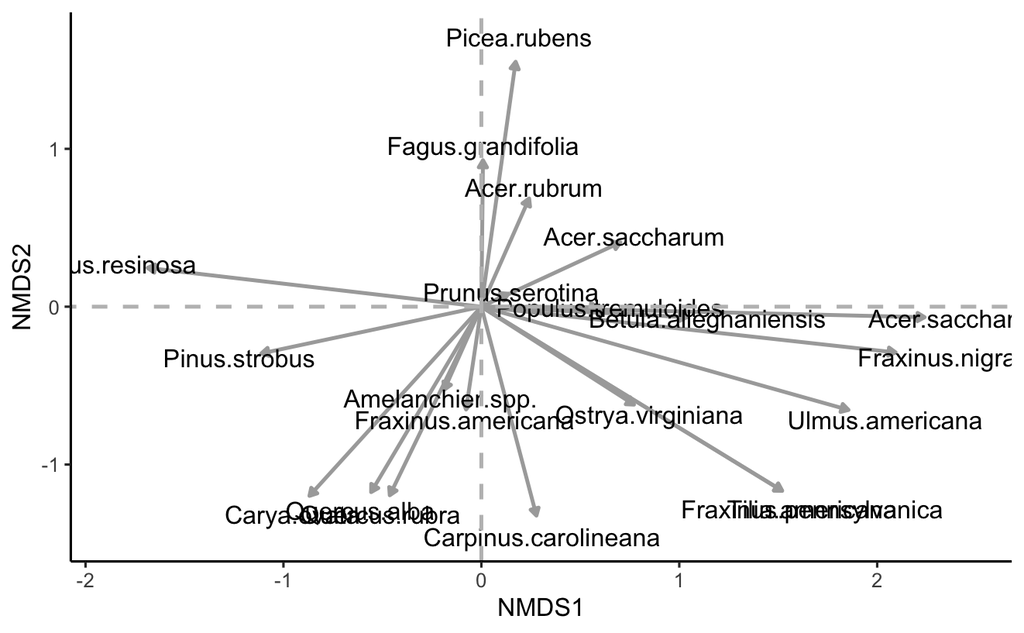

```r
p2<-ggplot()+
   geom_point(data = subset(ForPlotting, score =="sites"),
              mapping = aes(x = NMDS1, y = NMDS2),
              color = "black",
              alpha = 0)+
   geom_segment(data=subset(ForPlotting, score == "species"),
                 mapping = aes(x = 0, y = 0, xend = NMDS1, yend=NMDS2),
                 arrow = arrow(length = unit(0.015, "npc"),
               type = "closed"),
                 color = "darkgray",
                 size = 0.8)+
   geom_text(data = subset(ForPlotting, score == "species"),
             mapping = aes(label = label, x = NMDS1*1.1, y=NMDS2*1.1))+
   geom_abline(intercept = 0, slope = 0, linetype = "dashed", size = 0.8, color = "gray")+
   geom_vline(aes(xintercept = 0), linetype = "dashed", size = 0.8, color = "gray")+
   theme(
      panel.grid.major = element_blank(),
      panel.grid.minor = element_blank(),
      panel.background = element_blank(),
      axis.line = element_line(color = "black")
   )
p2
```

Finally, plot them together using `ggpubr`

```r
TreeCountOrdination<-ggarrange(p1,p2,ncol = 1)
```

And save the plot!

```r
ggsave(here("Code", "TreeCountOrdination.png"), plot = TreeCountOrdination, device = "png")
```